# Final Project - Curated Bladder Data

John Kidd, Teeranan(Ben) Pokaprakarn, Sarah Reifeis

12/06/2017

Our group topic is cancer genomics, and we worked with the curatedBladderData dataset for this project, specifically attempting to mimic results from this [paper](https://www.ncbi.nlm.nih.gov/pubmed/15930339). To give you a little background on why we care about bladder cancer, we have some info below from the American Cancer Society to bring it into focus.

# Context for Bladder Cancer

The [American Cancer Society](https://www.cancer.org/cancer/bladder-cancer/about/key-statistics.html) estimates that there will be around 80,000 new cases of bladder cancer in the US in 2017, constituting appromximately 5% of all new cancer cases. Of these, men are expected to be affected at 3 times the rate of women, and there are about 17,000 total deaths expected.

Bladder cancer tumors can be divided into two groups: superficial and muscle-invasive. This relates to staging of cancer (0/a, 1, 2, 3, 4) as follows. Generally, the 0 or a stage & 1 are considered superficial tumors because they haven’t yet invaded the muscular wall of the bladder; stage 2 is characterized by the tumor invading the muscle wall of the bladder, and so stage 2 and beyond are classified as muscle-invasive tumors. Around half of all bladder cancers are first detected before becoming muscle-invasive.

# Background on Our Data

The particular dataset we chose to use in the curatedBladderData collection contains gene expression of 6225 genes for each of 80 subjects with bladder tumors. Some covariates of interest that we make use of later on are tumor subtype (superficial, muscle-invasive) and tumor stage.

As we began working with the dataset, it became apparent that there was an abundance of missing data for gene expression. In figuring out how to deal with this, we plotted gene expression standard deviation against the number of subjects with missing values for each gene.

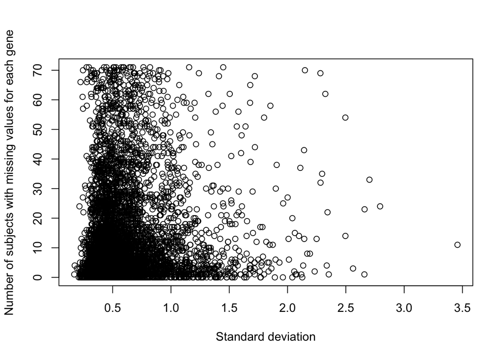

As you can see, there is still a lot of variance in some genes with a lot of missing data, so we don’t want to throw this info away. Hence, we made the decision to use median imputation to impute gene expression across genes for the remainder of our project.

The 80 bladder tumors were obtained frozen from the tissue bank of the UCSF Comprehensive Cancer Center, and the tumors were staged according to professionals from the American Joint Committee on Cancer. Of note, the paper mentioned above claims that the 80 tumors can be broken up into 17 stage a, 10 stage 1, 15 stage 2, 25 stage 3, and 13 stage 4. However, upon examining the data ourselves, we believe this to be a typo in the paper or there may be an error present in the dataset. From the dataset we used, we have that there are 17 stage a, 10 stage 1, 14 stage 2, 26 stage 3, and 13 stage 4, and this is the data we will use for the remainder of our project.

# Roadmap

We have 3 main objectives that we will cover throughout this project:

Firstly, we attempt to recreate a cluster dendrogram to resemble Fig 1 in the paper mentioned above. Several methods for clustering will be explored and compared to Fig 1 of the paper.

Secondly, we investigate differences in gene expression levels for superficial and muscle-invasive tumors using heatmaps. In the paper, they created a heatmap (Fig 2) using an unspecified subset of around 2k genes (same set they used to create their cluster dendrogram). We didn’t have a way to find out what these genes were, so we created several of our own subsets and generated heatmaps and compared them.

Thirdly, we fit our subsets of genes using various methods to predict, based on expression, whether each tumor should be classified as superficial or muscle-invasive. We then used 5-fold cross-validation to obtain a mis-classification rate for each combination of fitting method and gene subset. To try and get a more accurate measurment of the true mis-classification rate, we run 10 cross-validations and take the average error across the 10 iterations.

## Preprocessing done by the paper

1. Signal intensity values of each element were extracted using the GenePix software.
2. Intensities were then corrected by subarray median centering followed by global locally weighted scatterplot smoothing correction
3. Values are normalized and median centered

# Clusters

In this section, we attempt to recreate Figure 1 in the paper with a few differences described below.

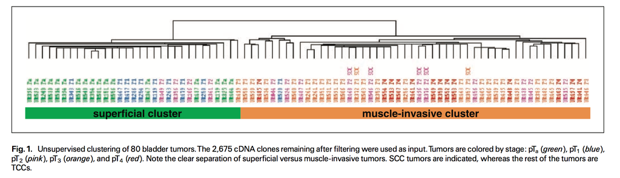

### Clustering method from the paper

1. Filtering of genes: log2 ratios were filtered to include only these clones showing expression ratios in at least 80% of samples analyzed Only clones that had |log2 ratio|>2 in at least one sample were used
2. Unsupervised hierarchical clustering
3. Linkage method: Average linkage (join clusters whose avg distance are the smallest)
4. Distance/Similarity matrix: uncentered Pearson correlation metric
5. Bottom-up clustering direction

### Justification for our method

We cannot perform the filtering as described by the paper, hence we chose a few other ways from class we can try to reduce the number of dimensions. We also explore other methods of clustering in order to examine if the choices about the clustering algorithm with regards to imputation, filtering, and clustering method made by the author make a difference in the validity of the result. In other words, we examine if the validity of the claim in the paper is sensitive to these choices.

### What we did

We try three different approaches of clustering with different choices of how we select the genes to include, and the imputation. We also use a slightly different clustering algorithm from the paper. We chose hierarchical clustering with ward’s method.

##### First approach:

Filtering: we just select top 100 genes with highest variance (before imputing);

Imputation: Median impute

##### Second approach:

Nonmissing genes only (621 genes left);

10 principal components

##### Third approach

Median Impute ; 500 random genes

## Cluster with the top 100 genes with the highest variance

```
## [1] 80 80
```

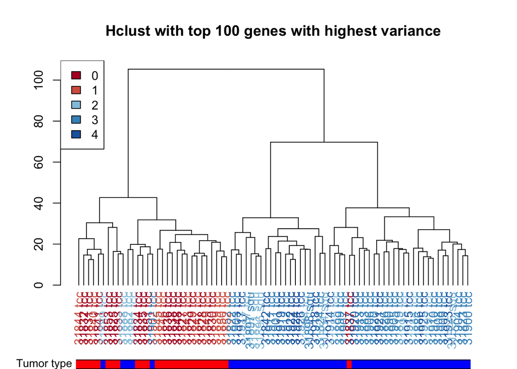

Number 0 to 4 denote the stage of tumor. The red color in the colored bar at the bottom denotes superficial tumor (stage 0 and stage 1) while blue denotes the muscle invasive tumor. ‘tcc’ and ‘squ’ refers to the histological type.

```
##
## cluster invasive superficial
##       1       48           1
##       2        5          26
```

```
##
## cluster squamous tcc
##       1        6  43
##       2        0  31
```

```
##
## cluster  0  1  2  3  4
##       1  1  0 10 25 13
##       2 16 10  4  1  0
```

We see here that the two clusters are distinct in terms of the proportion of superficial and muscle-invasive tumor. we only have 6 misclassification (5 in superficial and 1 in muscle invasive). Note also that all the ‘squamous’ histological type tumor are in the same cluster. This is consistent with the results reported by the paper which also have 6 similar misclassification. This shows that at least in this example, the result is not sensitive to the choice of filtering, imputation, and clustering algorithm. We can still clearly distinguish the superficial and the muscle invasive tumor based on the unsupervised cluster.

## Clustering with only 10 Principal Components

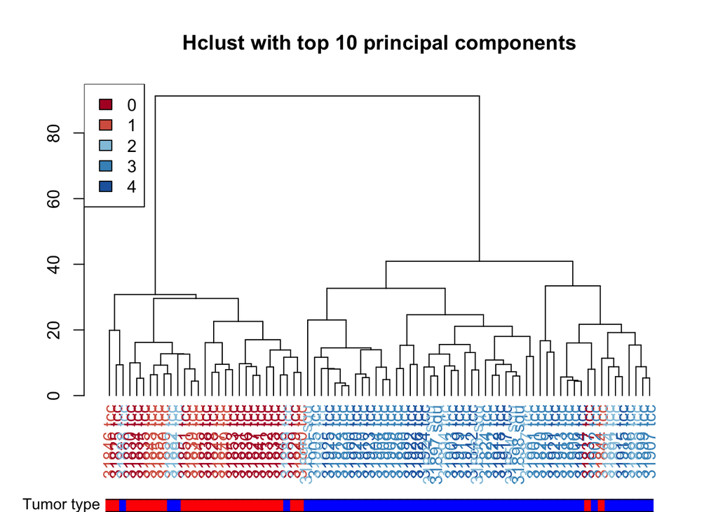

```r
cluster <- cutree(hc, k=2)
table(cluster, pData(a1)$summarystage)
```

```
##
## cluster invasive superficial
##       1       49           2
##       2        4          25
```

Here we also have 6 misclassification (4 in superficial and 2 in muscle invasive). This shows that even with just 10 prinicipal components based on the 621 non-missing genes compared to the 2,675 genes the paper uses after filtering, we can still have two distinct clusters with the same misclassifications.

## Clustering with 500 random genes

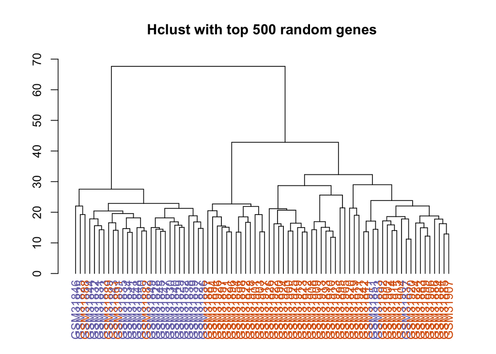

An example of a hierachical cluster of 500 random genes. We can still see that there are two distinct clusters.

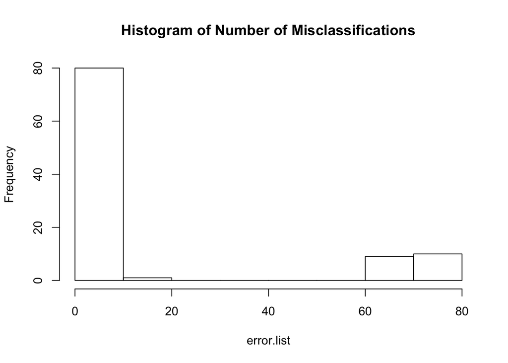

The histogram shows that 80 percent of the times when we randomly select 500 genes, we still obtain less than 10 misclassification. This shows that there might be some batch effect across the genes between the two types of tumors because even when we randomly pick genes, we can still differentiate the two types of tumor. Another possible explanation is that there are signals in a lot of these genes and therefore even when we randomly pick, we are still getting some signals.

# Heatmaps

# Cross-Validation Errors

# Conclusion